# Homework 3

## Problem 4: Simulating a random variable (7pts)

Define a random variable $X$ with density
$$f_X(t) = \begin{cases}
\frac12\sin t &\mbox{ if } 0 \le t \le \pi \\
0 &\mbox{ otherwise. }
\end{cases}$$

The probability density function (pdf) is visualized below.

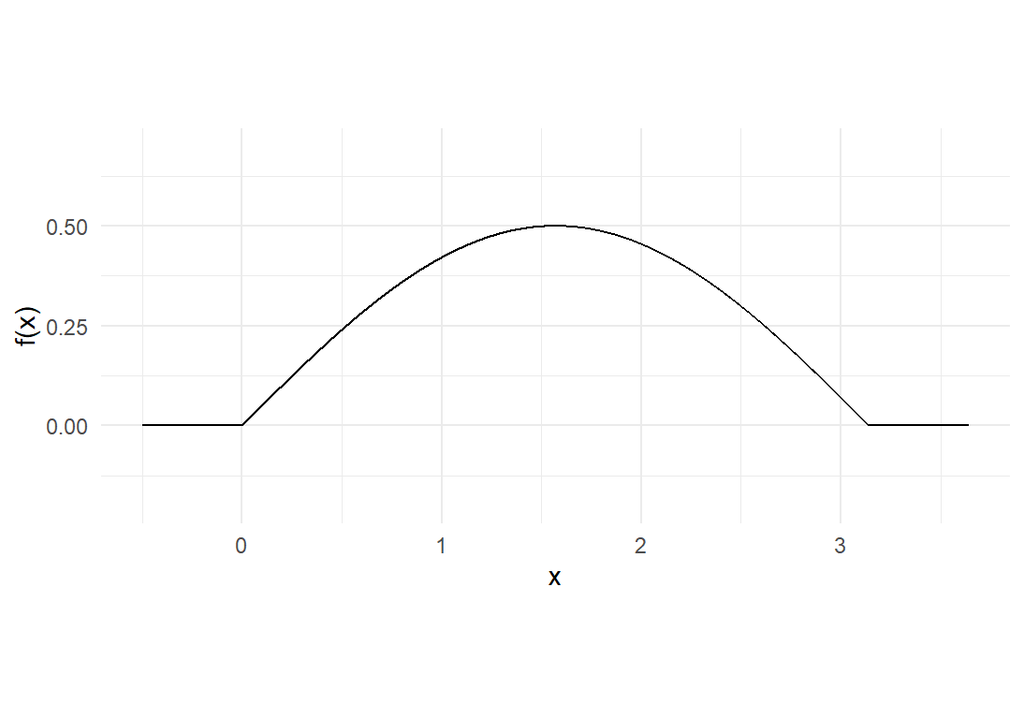

This means that the cumulative distribution function is
$$F_X(t)=\int_0^tf_X(u)du=\frac12-\frac{1}{2}\cos(t)$$
for $0 \le t \le \pi$, (and $F_X(t)=0$ for $t<0$ and $F_X(t) = 1$ for $t \ge \pi$).

1. (3 points) Find $F^{-1}(x)$, the inverse CDF. *Hint: In `R` the `arc-cosine` function is `acos()`.*

```r
# inverse_cdf = arccos(1-2x)
```

2. (4 points) Write a function `rx(n)` (like `rbinom`) to sample from this random variable, where `n` is the size of the sample to be drawn. Then, use your function to draw sample of size 1000 and plot a histogram of the output to verify the results make sense.

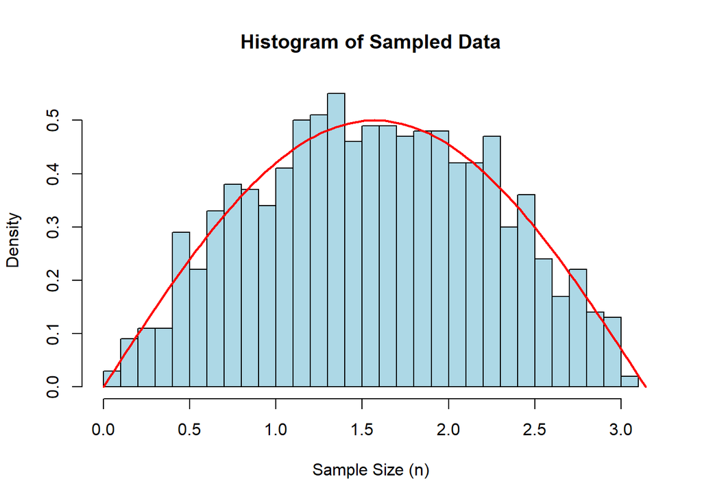

```r
# complete the function
set.seed(123)

rx = function(n) {
  u = runif(n)
  return(acos(1 - 2 * u))
}

sample_data <- rx(1000)

hist(sample_data, probability=TRUE, breaks=25,
     main="Histogram of Sampled Data",
     xlab="Sample Size (n)", col="lightblue")

curve(0.5 * sin(x), from=0, to=pi, col="red", add=TRUE, lwd=2)
```

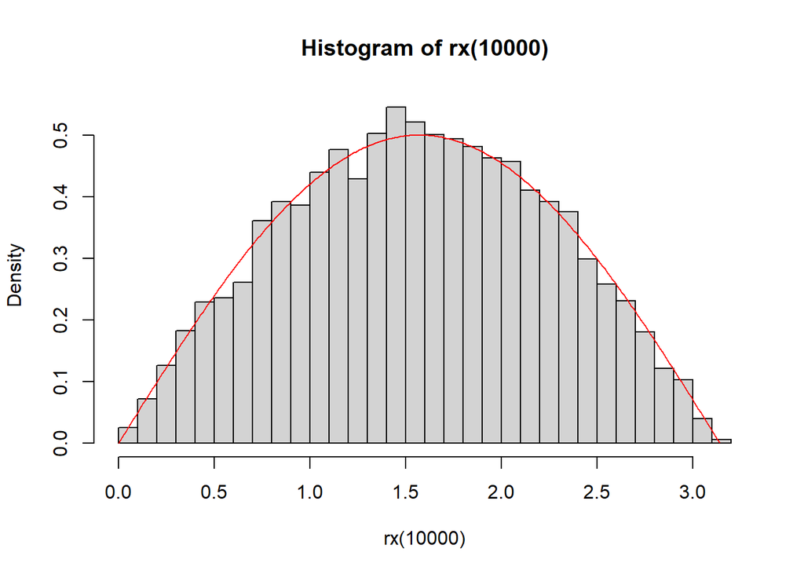

```r
# The histogram should look like the PDF we plotted above.
# Un-comment the following lines of code and check it looks correct

hist(rx(10000), probability=TRUE, breaks=25)
lines(x=seq(0,pi,.01), y=pdf_x(seq(0,pi,.01)), col='red')
```